# Exploring Von Koch and his Snowflakes (Fractals) Karim K. Kardous

- Show All Code
- Hide All Code
- View Source

## **Initial Setup**

I start by configuring the Python environment using [reticulate](https://rstudio.github.io/reticulate/), specifying a custom virtual environment and ensuring required packages (matplotlib and pillow) are installed. This setup step ensures Python and R work seamlessly together; granted ‘seamlessly’ might be over-reaching, but at least for this case, fairly commonly used modules, it was the case.

```r
library(reticulate)
invisible(
  capture.output({
    Sys.setenv(RETICULATE_PYTHON = "py_venv/bin/python3.9")
    reticulate::use_python("py_venv/bin/python3.9", required = TRUE)
    })
)

invisible(
  capture.output({
  use_python("py_venv/bin/python3.9", required = TRUE)
  py_config()
  py_install(c('matplotlib', 'pillow'), envname = "py_venv", pip = TRUE)
  })
)
```

With this chunk executed, R is now ready to run Python code from the designated virtual environment with the necessary libraries installed.

## **Image Configuration and Setup using matplotlib & [Pillow](https://pypi.org/project/pillow/)**

To overcome issues with displaying Pillow images directly in Quarto, I used matplotlib.pyplot to render and show images in the document. This section decomposes main first steps in creating the Snowflake fractals; before ‘completing’ the figure. Air quotes here implying that technically the figure can go up to infinity in its decomposition into smaller fragments or segments and equilateral triangles.

[figure not shown]

```python
from PIL import Image, ImageDraw
import matplotlib.pyplot as plt
import math

width = 1748
height = 1240
A0 = [1748 / 2 + 400, 800]
B0 = [1748 / 2 - 400, 800]

def koch(A, B, n, figsize = (3, 3), width = 2):
    vonkoch = Image.new('RGB', (width, height), (255, 255, 255))
    draw = ImageDraw.Draw(vonkoch)

    if(n == 0):
        draw.line((A, B), fill = (0, 0, 0), width = width)
        plt.figure(figsize = figsize)
        plt.imshow(vonkoch)
        plt.title('Initial AB segment (At Step n = 0)')
        plt.axis('off')
        plt.show()

koch(A0, B0, 0)
```

The next step is when n is > 0 to start creating the pattern. The idea, [Von Koch’s](https://nrich.maths.org/problems/von-koch-curve#:~:text=The%20Von%20Koch%20curve%20is,third%20of%20the%20original%20length.), is to split the segment into 4 parts, or segments: AM1, M1M2, M2M3, and M3B; almost forming a triangle M1M2M3, as shown below, with more steps involved including homothety and similarities

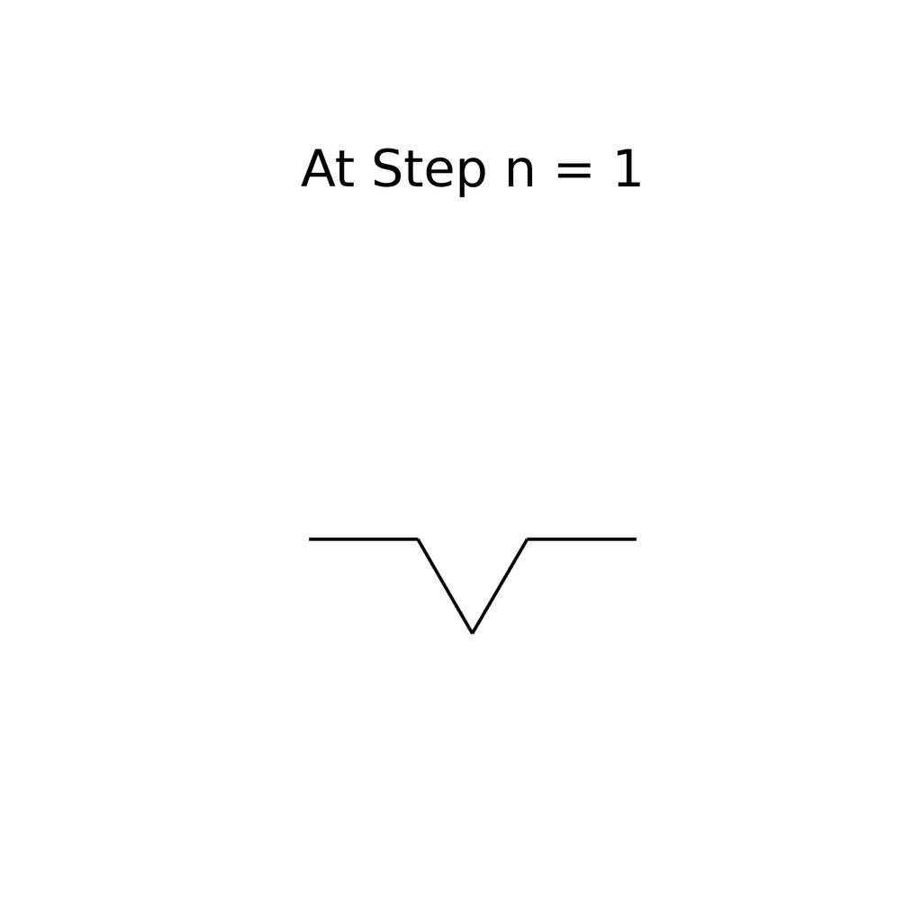

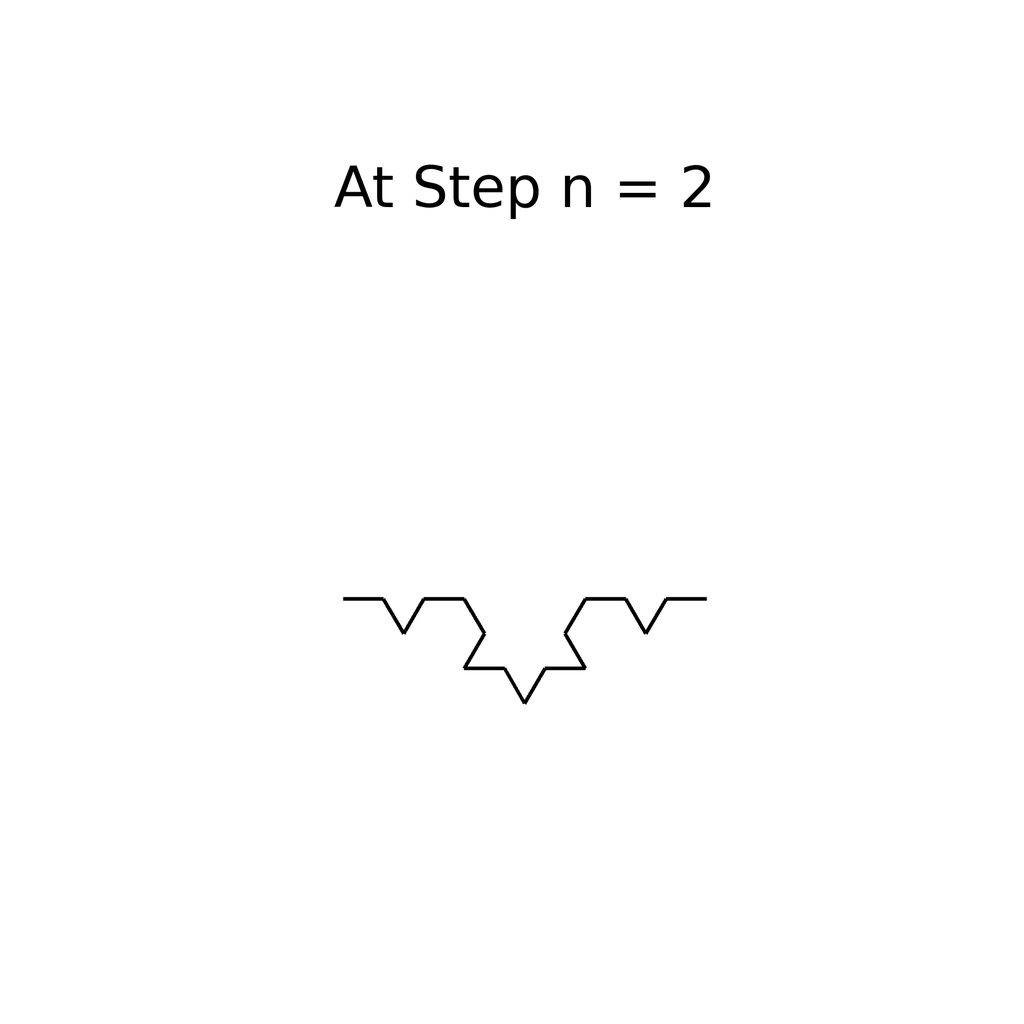

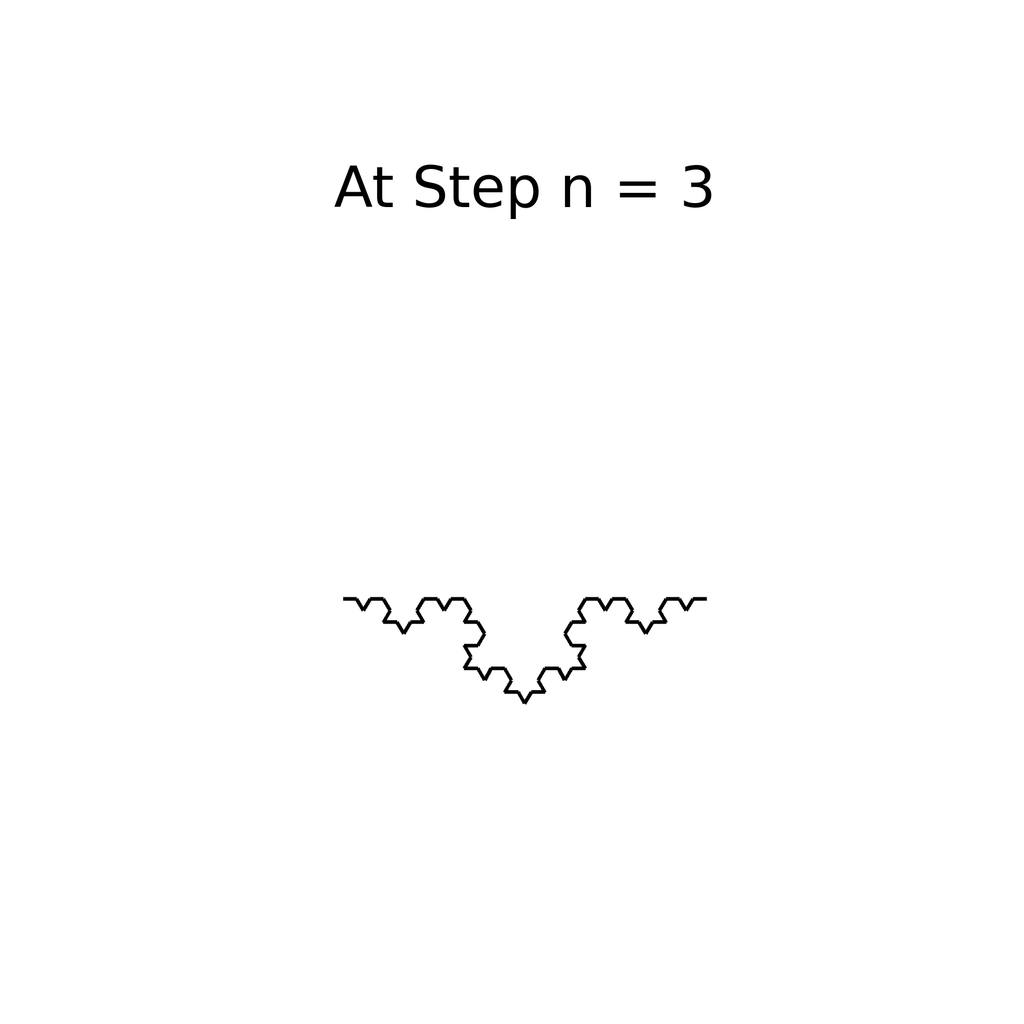

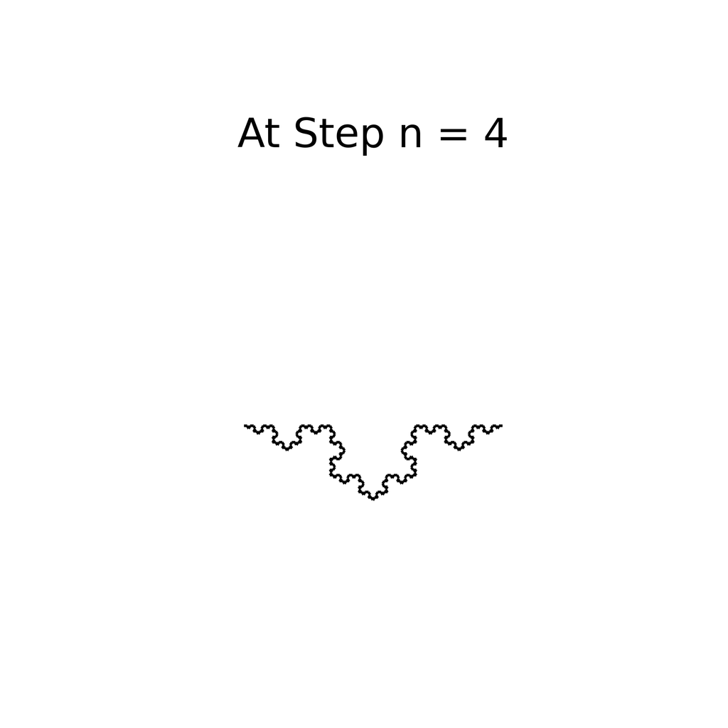

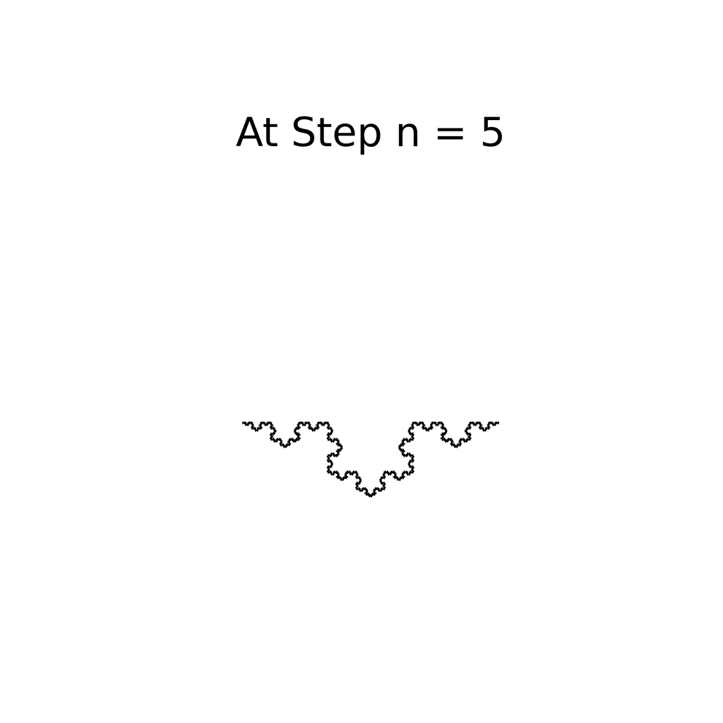

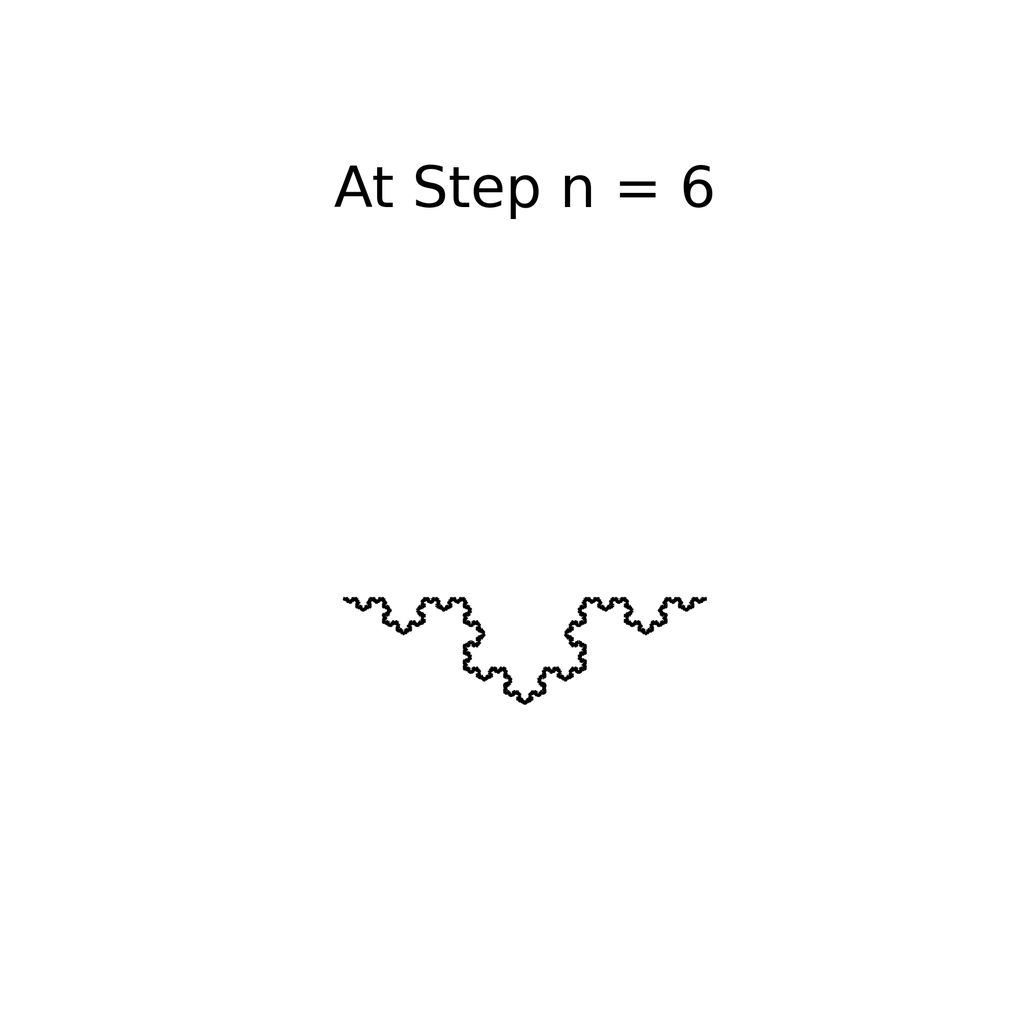

```python
def koch(draw, A, B, n, width = 8):
    if(n == 0):
        draw.line((A, B), fill = (0, 0, 0), width = width)
    else:
        M1 = sim(A, B, alpha = 0, mu = 1/3)
        M2 = sim(A, B, alpha = math.pi / 6, mu = 1/math.sqrt(3)) # alpha = 30° in radians, mu = scaling factor 1/√3
        M3 = sim(A, B, alpha = 0, mu = 2/3)
        koch(draw, A, M1, n - 1)
        koch(draw, M1, M2, n - 1)
        koch(draw, M2, M3, n - 1)
        koch(draw, M3, B, n - 1)

def sim(A, B, alpha, mu):
    C = [B[0] - A[0], B[1] - A[1]]
    D = [
        mu * (C[0] * math.cos(alpha) + C[1] * math.sin(alpha)),
        mu * (-C[0] * math.sin(alpha) + C[1] * math.cos(alpha))
    ]
    return [A[0] + D[0], A[1] + D[1]]

def draw_koch_wrapper(A, B, n, figsize = (3, 3)):
    image = Image.new('RGB', (width, height), (255, 255, 255))
    draw = ImageDraw.Draw(image)
    koch(draw, A, B, n)

    plt.figure(figsize = figsize)
    plt.imshow(image)
    plt.title(f'At Step n = {n}')
    plt.axis('off')
    plt.show()

for step in range(1, 7):
  draw_koch_wrapper(A0, B0, n = step)
```

## **Output Comment**

I think there reaches a point where each smaller fragments/ fractals reaches the size of a pixel, it appears to be at step no. of 6 from above; we can tell essentially that step 5 and 6 are virtually identical, at least under the pixel/dimensions set.

## **‘Completing’ the Snowflake ❄️**

Below we add the two missing sides of the initial equilateral triangle by computing the third vertex (via the `C0` rotation shown in the code) and recursively applying the Koch construction to all three edges, completing the full snowflake.

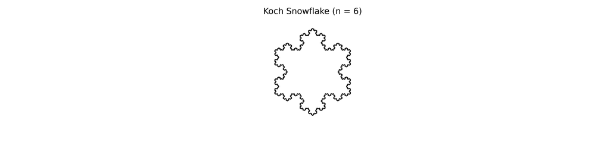

```python
def draw_koch_wrapper(A, B, n, figsize = (12, 3)):
    image = Image.new('RGB', (width, height), (255, 255, 255))
    draw = ImageDraw.Draw(image)

    # third point of the equilateral triangle (point C0)
    C0 = sim(B0, A0, alpha = math.pi / 3, mu = 1) # or a rotation of 60° and no homothety since we only want a mirror of what we have currently, no scaling needed
    # draw the three recursive edges
    koch(draw, A, B, n, width = 1)
    koch(draw, B, C0, n, width = 1)
    koch(draw, C0, A, n, width = 1)
    plt.figure(figsize = figsize)
    plt.imshow(image)
    plt.title(f'Koch Snowflake (n = {n})')
    plt.axis('off')
    plt.show()

draw_koch_wrapper(A0, B0, n = 6)
```

Overall, I thought it was interesting, aesthetically if nothing else, to see how with a few lines of code, fairly intricate and cool-looking images get created. Thanks for reading !